# Predicting execution quality of an exercise

Valentin Goverdovsky

31 January 2016

# Executive Summary

This document explores a dataset containing a variety of parameters related to weight-lifting exercises and attempts to use these parameters in assessing the quality of the exercise execution. We use cross-validation to tune the support vector machine prediction algorithm and achieve overall out of sample prediction accuracy of 98.57%.

# Data preprocessing

We first load the dataset into R and load the required machine learning and graphics libraries.

```r
library(caret)
library(e1071)
library(ggplot2)
set.seed(12345)
```

```r
wtLiftData <- read.csv(file = 'classeData.csv')
d <- dim(wtLiftData)
```

It’s clear that the data set has quite a substantial amount of data with some 160 features and 19622 data points. Before doing any additional exploration or analysis we split the dataset into training and testing portions, where 20% of the data is left for obtaining the final prediction accuracy and out of sample error rate.

```r
inTrainCV <- createDataPartition(wtLiftData$classe, p=0.8, list=FALSE)
trainingCVRaw <- wtLiftData[inTrainCV,]
testingRaw <- wtLiftData[-inTrainCV,]
```

By looking at the summary of the dataset, see Appendix - the printout is quite long, we observe that there is a large number of features with either NAs (e.g. max_roll_belt) or empty data (e.g. kurtosis_yaw_belt), thus we discard those with substantial amounts of missing data.

```r
notNA <- sapply(trainingCVRaw, function(i) {sum(is.na(i)) / length(i)}) < 0.9
trainingCVNotNA <- trainingCVRaw[, notNA]

emptyFeatures <- as.logical(apply(trainingCVNotNA, 2,
                                  function(x) any(grepl('#DIV/0!', x))))
trainingCVNotEmpty <- trainingCVNotNA[, !emptyFeatures]
```

If a particular feature exhibit close to zero variation across the dataset it is of little value in the prediction algorithm, therefore we should find any such values and exclude them from the feature-set.

```r
nsv <- nearZeroVar(trainingCVNotEmpty, saveMetrics=T)
trainingCVClean <- trainingCVNotEmpty[, !nsv$nzv]
```

Finally we don’t expect the index of the datasample to have any predictive value, similarly since every user was asked to perform all exercises at all the quality levels, user_name is also not expected to have any predictive value. In fact, the algorithm’s performance should be independent of user. In light of the above we exclude additional columns from out training dataset.

```r
idxCols <- grep('timestamp|user|X|num', names(trainingCVClean))
trainingCVClean <- trainingCVClean[, -idxCols]
```

This data manipulation leaves us with a total of 53 features to work with compared to the original 160. This is still a fairly large number. The original paper which used this dataset used a procedure based on correlation analysis to extract 17 ‘most important’ features and used Randof Forest prediction algorithm. Ufortunately the above-mentioned feature extraction procedure is described in a PhD thesis, and figuring out how exactly it works is beyond the scope of this course. Therefore we pursue a different approach, based on support vector machine prediction algorithms, which are fairly efficient at working with feature-rich dataset.

# Prediction

SVMs have a number of imporant parameters which affect the accuracy of the predictions, training speed, etc. One of the such parameters is the Cost (C) which is similary to the cost parameter in the regularised regression and penalises excessively large coefficients.

At this point we split our dataset into 30 folds and use cross-validation to train SVM with different values of Cost (C).

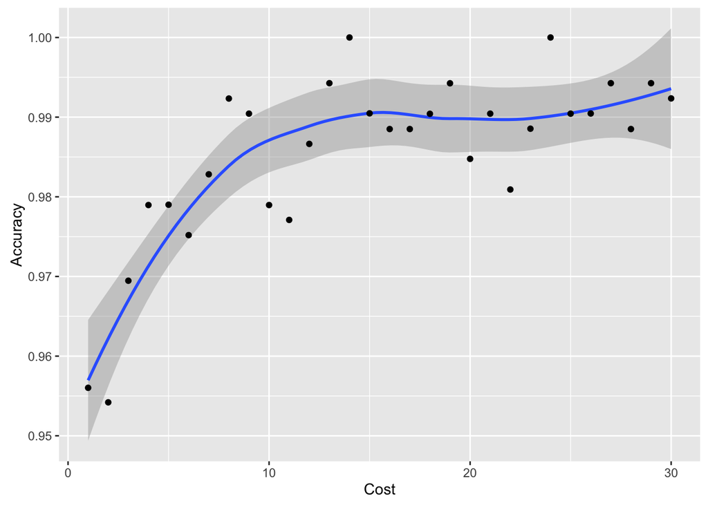

```r
trainingFolds <- createFolds(trainingCVClean$classe, k=30, list=TRUE, returnTrain=TRUE)

accuracy <- numeric(length(trainingFolds))

for (i in seq_along(trainingFolds)) {
    svmFit <- svm(classe~., data = trainingCVClean[trainingFolds[[i]],], cost = i)
    predictions <- predict(svmFit, trainingCVClean[-trainingFolds[[i]],])
    confMat <- confusionMatrix(predictions, trainingCVClean[-trainingFolds[[i]],]$classe)
    accuracy[i] <- confMat$overall[1]
}

qplot(y=accuracy,x=seq_along(accuracy),geom=c('smooth','point'), xlab = 'Cost', ylab = 'Accuracy')
```

From the plot of the accuracy vs. cost we can clearly see that the accuracy peaks or flattens out at C value of approximately 15, and this is the value that we choose to build the final prediction model.

```r
svmFinal <- svm(classe~., data = trainingCVClean, cost = 15)
```

Applying this model to the test set produces the following result.

```r
predictTest <- predict(svmFinal, testingRaw)
confMat <- confusionMatrix(predictTest, testingRaw$classe)
confMat
```

```
## Confusion Matrix and Statistics
##
##           Reference
## Prediction    A    B    C    D    E
##          A 1112    8    0    0    0
##          B    4  747    3    0    0
##          C    0    2  677   30    0
##          D    0    0    3  611    1
##          E    0    2    1    2  720
##
## Overall Statistics
##
##                Accuracy : 0.9857
##                  95% CI : (0.9815, 0.9892)
##     No Information Rate : 0.2845
##     P-Value [Acc > NIR] : < 2.2e-16
##
##                   Kappa : 0.9819
##  Mcnemar's Test P-Value : NA
##
## Statistics by Class:
##
##                      Class: A Class: B Class: C Class: D Class: E
## Sensitivity            0.9964   0.9842   0.9898   0.9502   0.9986
## Specificity            0.9971   0.9978   0.9901   0.9988   0.9984
## Pos Pred Value         0.9929   0.9907   0.9549   0.9935   0.9931
## Neg Pred Value         0.9986   0.9962   0.9978   0.9903   0.9997
## Prevalence             0.2845   0.1935   0.1744   0.1639   0.1838
## Detection Rate         0.2835   0.1904   0.1726   0.1557   0.1835
## Detection Prevalence   0.2855   0.1922   0.1807   0.1568   0.1848
## Balanced Accuracy      0.9968   0.9910   0.9899   0.9745   0.9985
```

This demonstrates that our SVM achieves overall out of sample accuracy of 98.57% and similarly high accuracy for each of the individual values of *classe* variable.

# Conclusion

We have analysed the weight training dataset which contains data on the quality of the execution of a particular exersice. An SVM has been trained and cross-validated to predict the *classe* variable. The overall out of sample accuracy achieved by this method was 98.57%.

# Appendix

```r
summary(wtLiftData)
```

```
##        X            user_name    raw_timestamp_part_1 raw_timestamp_part_2
##  Min.   :    1   adelmo  :3892   Min.   :1.322e+09    Min.   :   294
##  1st Qu.: 4906   carlitos:3112   1st Qu.:1.323e+09    1st Qu.:252912
##  Median : 9812   charles :3536   Median :1.323e+09    Median :496380
##  Mean   : 9812   eurico  :3070   Mean   :1.323e+09    Mean   :500656
##  3rd Qu.:14717   jeremy  :3402   3rd Qu.:1.323e+09    3rd Qu.:751891
##  Max.   :19622   pedro   :2610   Max.   :1.323e+09    Max.   :998801
##
##           cvtd_timestamp  new_window    num_window      roll_belt
##  28/11/2011 14:14: 1498   no :19216   Min.   :  1.0   Min.   :-28.90
##  05/12/2011 11:24: 1497   yes:  406   1st Qu.:222.0   1st Qu.:  1.10
##  30/11/2011 17:11: 1440               Median :424.0   Median :113.00
##  05/12/2011 11:25: 1425               Mean   :430.6   Mean   : 64.41
##  02/12/2011 14:57: 1380               3rd Qu.:644.0   3rd Qu.:123.00
##  02/12/2011 13:34: 1375               Max.   :864.0   Max.   :162.00
##  (Other)         :11007
##    pitch_belt          yaw_belt       total_accel_belt kurtosis_roll_belt
##  Min.   :-55.8000   Min.   :-180.00   Min.   : 0.00             :19216
##  1st Qu.:  1.7600   1st Qu.: -88.30   1st Qu.: 3.00    #DIV/0!  :   10
##  Median :  5.2800   Median : -13.00   Median :17.00    -1.908453:    2
##  Mean   :  0.3053   Mean   : -11.21   Mean   :11.31    -0.016850:    1
##  3rd Qu.: 14.9000   3rd Qu.:  12.90   3rd Qu.:18.00    -0.021024:    1
##  Max.   : 60.3000   Max.   : 179.00   Max.   :29.00    -0.025513:    1
##                                                        (Other)  :  391
##  kurtosis_picth_belt kurtosis_yaw_belt skewness_roll_belt
##           :19216            :19216              :19216
##  #DIV/0!  :   32     #DIV/0!:  406     #DIV/0!  :    9
##  47.000000:    4                       0.000000 :    4
##  -0.150950:    3                       0.422463 :    2
##  -0.684748:    3                       -0.003095:    1
##  -1.750749:    3                       -0.010002:    1
##  (Other)  :  361                       (Other)  :  389
##  skewness_roll_belt.1 skewness_yaw_belt max_roll_belt     max_picth_belt
##           :19216             :19216     Min.   :-94.300   Min.   : 3.00
##  #DIV/0!  :   32      #DIV/0!:  406     1st Qu.:-88.000   1st Qu.: 5.00
##  0.000000 :    4                        Median : -5.100   Median :18.00
##  -2.156553:    3                        Mean   : -6.667   Mean   :12.92
##  -3.072669:    3                        3rd Qu.: 18.500   3rd Qu.:19.00
##  -6.324555:    3                        Max.   :180.000   Max.   :30.00
##  (Other)  :  361                        NA's   :19216     NA's   :19216
```

[output cut: 313 more lines]

```
##  Min.   :-446.00   Min.   :-1280.0   Min.   :-896.0   Min.   :-973.0
##  1st Qu.:-182.00   1st Qu.: -616.0   1st Qu.:   2.0   1st Qu.: 191.0
##  Median : -39.00   Median : -378.0   Median : 591.0   Median : 511.0
##  Mean   : -55.29   Mean   : -312.6   Mean   : 380.1   Mean   : 393.6
##  3rd Qu.:  26.00   3rd Qu.:  -73.0   3rd Qu.: 737.0   3rd Qu.: 653.0
##  Max.   : 291.00   Max.   :  672.0   Max.   :1480.0   Max.   :1090.0
##
##  classe
##  A:5580
##  B:3797
##  C:3422
##  D:3216
##  E:3607
##
##
```